# Coloc_Results

2023-07-25

# Methods

We further perform colocalization analysis of GWAS signals (nucDNA-mtDNA trans eQTL) with expression quantitative trait loci (nucDNA cis-eQTL) to connect GWAS signals to candidate causal genes and prioritize likely relevant tissues for the mtDNA trans-eQTL (nuclear DNA variants - mitochondrial DNA genes) interaction. We employed a method that allows us to assess the overlap and shared genetic signals between GWAS and eQTL data. The method utilizes the assumption that the number of individuals and the pairwise Pearson’s correlations of genotype (LD) are consistent between the two datasets and that both the phenotype and gene expression data have at least one significant variant. Our colocalization method offers several advantages, including the ability to divide eQTL and GWAS variants into two groups based on their directions of effect (Congruence/Incongruence). We have chosen to use the smallest p-value as the CollapseMethod for selecting variants, and we also performed a simple sample-size-weighted meta-analysis (weighted Z-test) for each variant using the CollapseMethod=“meta”. Additionally, we have selected a range of flanking genome (3000000kb) to ensure that GWAS variants fall within the locus of interest (LOI). Although the method can incorporate LD information, we have not yet included it in the analysis. We assessed the enrichment of candidate gene eQTLs among GWAS-significant variants using Fisher’s exact test. Furthermore, we computed and displayed the Pearson correlation coefficient and p-value of correlation between the GWAS p-values ($P_{GWAS}$) and eQTL p-values ($P_{eQTL}$).

# Results

## Quick Summary

- $P_{GWAS}$ Vs $P_{eQTL}$ - $R2 > 0.6$: 52 nDNA genes colocalise in 71 instances
- $P_{GWAS}$ Vs $P_{eQTL}$ - $R2 > 0.8$: 10 nDNA genes colocalise in 17 instances
- $P_{GWAS}$ Vs $P_{eQTL}$ - $R2 < -0.6$: 15 nDNA genes colocalise in instances
- $P_{GWAS}$ Vs $P_{eQTL}$ - $R2 < -0.8$: 1 nDNA gene colocalise in 1 instance

## $R^2>0.8$

| Gene | Correlation | Pvalue | key |
| --- | --- | --- | --- |
| LRPPRC | 0.967 | 0.00e+00 | Cells_Cultured_fibroblasts_ENSG00000198888_rs6720846 |
| SNHG15 | 0.897 | 1.02e-266 | Brain_Cerebellar_Hemisphere_ENSG00000198938_rs2304693 |
| SNHG15 | 0.928 | 9.34e-222 | Brain_Putamen_basal_ganglia_ENSG00000198938_rs2304693 |
| SNHG15 | 0.925 | 1.37e-217 | Brain_Putamen_basal_ganglia_ENSG00000198712_rs10951795 |
| INPP5E | 0.917 | 8.22e-200 | Brain_Caudate_basal_ganglia_ENSG00000198938_rs10870165 |
| SNHG15 | 0.829 | 7.93e-152 | Muscle_Skeletal_ENSG00000198712_rs10951791 |
| SNHG15 | 0.829 | 7.93e-152 | Muscle_Skeletal_ENSG00000198938_rs10951791 |
| SNHG15 | 0.841 | 1.28e-118 | Artery_Tibial_ENSG00000198712_rs2304693 |
| SNHG15 | 0.841 | 1.28e-118 | Artery_Tibial_ENSG00000198938_rs2304693 |
| SNHG15 | 0.809 | 3.70e-86 | Brain_Frontal_Cortex_BA9_ENSG00000198899_rs72597447 |
| ASTN1 | 0.817 | 3.01e-77 | Brain_Nucleus_accumbens_basal_ganglia_ENSG00000198938_rs72716840 |
| IL20RA | 0.803 | 1.00e-50 | Adipose_Visceral_Omentum_ENSG00000198938_rs9376244 |
| YKT6 | 0.909 | 3.39e-46 | Esophagus_Muscularis_ENSG00000198712_rs111656118 |
| TTC9C | 0.806 | 4.39e-43 | Brain_Frontal_Cortex_BA9_ENSG00000198727_rs112691937 |
| MEIS3P2 | 0.823 | 2.32e-14 | Adrenal_Gland_ENSG00000212907_rs4925043 |
| NXF1 | 0.817 | 2.12e-03 | Cells_EBV-transformed_lymphocytes_ENSG00000198712_rs540613 |
| KRTCAP2 | 0.879 | 1.21e-01 | Brain_Cerebellar_Hemisphere_ENSG00000212907_rs4845671 |

## Example 1:

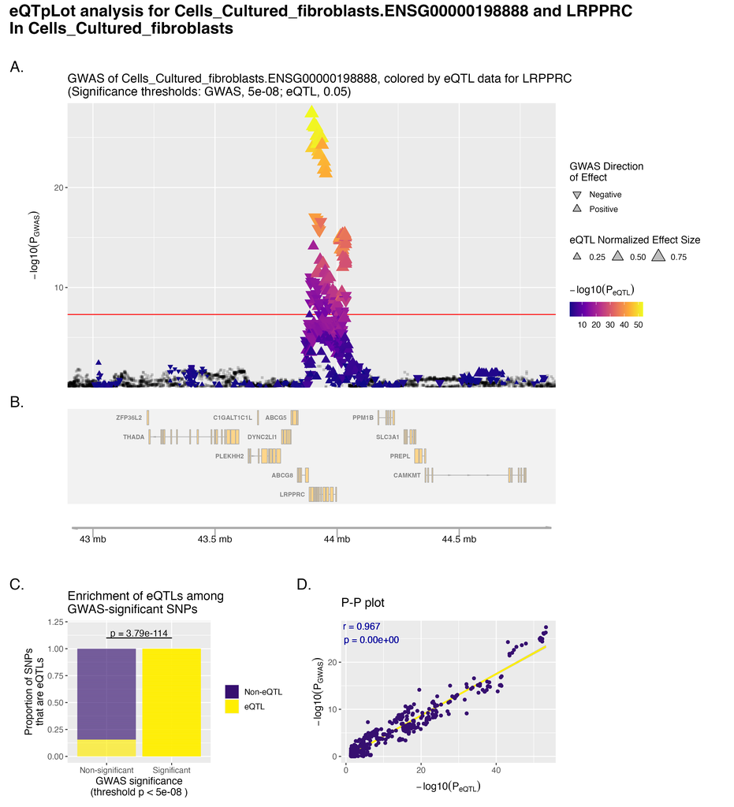

where: a) The size of each triangle corresponds to the eQTL normalized effect size (NES) for each variant, while the directionality of each triangle is set to correspond to the direction of effect for the variant on the GWAS trait. c) Enrichment of candidate gene eQTLs among GWAS-significant variants is determined by Fisher’s exact test. d) Visualize correlation between $P_{GWAS}$ and $P_{eQTL}$, including Pearson correlation coefficient and p-value of correlation

## $top_{20} Pval$

| Gene | Correlation | Pvalue | key |
| --- | --- | --- | --- |
| LRPPRC | 0.967 | 0.00e+00 | Cells_Cultured_fibroblasts_ENSG00000198888_rs6720846 |
| SNHG15 | 0.897 | 1.02e-266 | Brain_Cerebellar_Hemisphere_ENSG00000198938_rs2304693 |
| SNHG15 | 0.928 | 9.34e-222 | Brain_Putamen_basal_ganglia_ENSG00000198938_rs2304693 |
| SNHG15 | 0.925 | 1.37e-217 | Brain_Putamen_basal_ganglia_ENSG00000198712_rs10951795 |
| INPP5E | 0.917 | 8.22e-200 | Brain_Caudate_basal_ganglia_ENSG00000198938_rs10870165 |
| SNHG15 | 0.829 | 7.93e-152 | Muscle_Skeletal_ENSG00000198712_rs10951791 |
| SNHG15 | 0.829 | 7.93e-152 | Muscle_Skeletal_ENSG00000198938_rs10951791 |
| ZSCAN23 | 0.550 | 1.89e-150 | Prostate_ENSG00000228253_rs62401437 |
| ZNF603P | 0.524 | 2.45e-128 | Prostate_ENSG00000228253_rs62401437 |
| HLA-DOB | -0.386 | 1.59e-125 | Spleen_ENSG00000198804_rs2857102 |
| SNHG15 | 0.841 | 1.28e-118 | Artery_Tibial_ENSG00000198712_rs2304693 |
| SNHG15 | 0.841 | 1.28e-118 | Artery_Tibial_ENSG00000198938_rs2304693 |
| SNORA5A | 0.763 | 1.14e-113 | Adipose_Subcutaneous_ENSG00000198938_rs4724362 |
| LRPPRC | 0.739 | 9.47e-102 | Cells_EBV-transformed_lymphocytes_ENSG00000198888_rs4953032 |
| PWRN4 | 0.535 | 5.44e-99 | Brain_Hypothalamus_ENSG00000228253_rs77812651 |
| LINC01085 | 0.740 | 1.37e-93 | Lung_ENSG00000198712_rs13114923 |
| NOC3L | -0.604 | 4.01e-92 | Stomach_ENSG00000198763_rs507728 |
| SNHG15 | 0.712 | 4.51e-92 | Cells_Cultured_fibroblasts_ENSG00000198886_rs2304693 |
| SNHG15 | 0.809 | 3.70e-86 | Brain_Frontal_Cortex_BA9_ENSG00000198899_rs72597447 |
| MRPL28 | 0.785 | 8.75e-84 | Esophagus_Mucosa_ENSG00000198786_rs743961 |